# I. Házi feladat egy lehetséges megoldása

## 1. feladat

Az alábbi függvény egy véletlenszerű adatsort generál.

```python
def some_random_coeffs():
    a = 10 * np.random.rand() - 2.5
    b = 20 * np.random.rand() - 5
    c = 100 * np.random.rand() - 50
    return a, b, c

def some_random_data(a, b, c, N):
    x = np.linspace(-N, N, 2 * N + 1)
    sigma = 10 * (np.random.rand(x.shape[0]) + 1)
    y = np.random.normal(a * x**2 + b * x + c, sigma)
    return x, y, sigma

def random_data_with_outliers(a, b, c, N, M):
    x, y, sigma = some_random_data(a, b, c, N)
    idx = np.random.randint(0, 2 * N, M)
    y[idx] = np.min(y) + np.random.rand() * (np.max(y) - np.min(y))
    return x, y, sigma
```

Először is, generáljuk le az adatsorainkat, és nézzünk róluk egy sokatmondó ábrát!

```python
# adatsor legenerálása:
a, b, c = some_random_coeffs()
x, y, sigma = some_random_data(a, b, c, 10)
np.savetxt('adatsor.txt', np.transpose([x, y, sigma]))
```

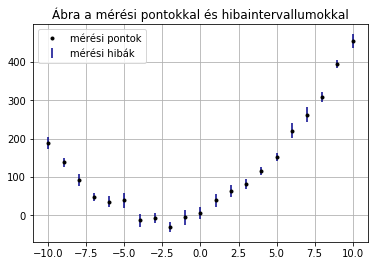

```python
plt.errorbar(x,y,sigma,linestyle ='',color='darkblue',label='mérési hibák')
plt.plot(x,y,marker='.',linestyle='',color='black',label='mérési pontok')
plt.title("Ábra a mérési pontokkal és hibaintervallumokkal")
plt.grid()
plt.legend()
```

### Írjunk rövid programot, mely az adatokra parabolát illeszt!

- A program ne beépített függvényillesztő rutint használjon, hanem végezze el a számolást az órán ismeretett $X_{ij}$ mátrix előállításával és lineáris egyenletrendszer megoldásával
- Az egyenletrendszer megoldására tetszőleges függvénykönyvtár használható.
- Lefoglaljuk a tervmátrixnak megfelelő helyet
- Egy for ciklus segítségével feltöltjük a megfelelő értékekkel

```python
Mat = np.empty((x.shape[0],3))
for i in range(x.shape[0]):
    for j in range(3):
        Mat[i,j] = (x[i]**j)/sigma[i]
```

- b vektornak is helyet foglalunk
- az előzőhöz hasonlóan elemekkel töltjük fel

```python
b = np.empty((x.shape[0],1))
for i in range(x.shape[0]):
    b[i] = (y[i])/sigma[i]
```

- elvégezzük a mmátrixműveleteket
- "a"-ban tároljük a chi^2-et minimalizáló paramétereket
- majd "a" minimalizált értékeinek segítségével polinomot készítünk x adataihoz igazodva

```python
M = np.dot(Mat.T,Mat)
N = np.dot(Mat.T,b)
a = np.linalg.solve(M,N)
z = polyval(x,a,False)
```

És most már (majdnem) teljes nyugalommal ábrázolhatjuk;

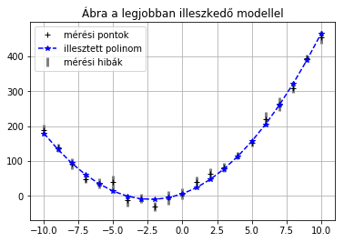

```python
plt.title("Ábra a legjobban illeszkedő modellel")
plt.errorbar(x,y,sigma,ls='',c='grey',lw=3,label='mérési hibák')
plt.plot(x,y,marker='+',ls='',c='black',label='mérési pontok')
plt.plot(x,z,'--*',c='b',label='illesztett polinom')
plt.grid()
plt.legend()
```

### Számítsuk ki a legjobban illeszkedő modell esetében a redukált $\chi^2$ értékét!

$\chi^2$ kiszámolható a következőképpen:

$$ \chi^2(\mathbf{a}) = \sum_i \frac{\left[ y(\mathbf{a}, \mathbf{x}_i) - y_i \right]^2}{\sigma_i^2} = \sum_i \frac{\left[ \sum_k a_k f_k(\mathbf{x}_i) - y_i \right]^2}{\sigma_i^2} $$

Ebből pedig továbbszámítva a redukált $\chi^2$ értéke:

$$ \chi^2_\nu = \frac{\chi^2}{\nu}, $$

ahol $\nu = N - M$ a szabadsági fokok száma, azaz a mérési adatpontok száma mínusz az illesztendő paraméterek száma. Jó illesztésről akkor beszélhetünk, ha $\chi^2_\nu \approx 1$.

Ez alapján az előbb kiszámolt paramétereket felhasználva a redulált $\chi^2$ értéke:

```python
chi2 = ((z-y)**2)/(sigma**2)     # chi^2
sum_chi2 = np.sum(chi2)

v = len(x) - len(a)
r_chi2 = sum_chi2 / v            # redukált chi^2

print(r_chi2)
```

```
0.6000733511110118
```

Látszik, hogy a kapott érték valóban jól megközelíti az egyet

## 2. feladat

Az alábbi függvényhívás olyan adatsort generál, amely kilógó (a megadott hibaértékkel nem jól jellemzett, vagy sok szigma értékkel eltérő) adatpontokat is tartalmaz.

```python
a, b, c = some_random_coeffs()
x, y, sigma = random_data_with_outliers(a, b, c, 10, 3)
```

Írjunk programot, mely a $3\sigma$-nál jobban kilógó pontok elhagyásával, két lépésben, illetve iteratív módon végzi el a parabolaillesztést!

- Függvény a polinom-illesztéshez, mely az illesztett paraméterekkel tér vissza;

```python
def illesztes(x,y,sigma):
    from numpy.polynomial.polynomial import polyval
    Mat = np.empty((x.shape[0],3))
    for i in range(x.shape[0]):   # tervmátrix feltöltése a megadott értékekkel
        for j in range(3):
            Mat[i,j] = (x[i]**j)/sigma[i]

    b = np.empty((x.shape[0],1))    # b vektor helyének lefoglalása
    for i in range(x.shape[0]):     # b vektor feltöltése elemekkel
        b[i] = (y[i])/sigma[i]

    M = np.dot(Mat.T,Mat)     # mátrixműveletek elvégzése :
    N = np.dot(Mat.T,b)
    a = np.linalg.solve(M,N)  # 'a' tartalmazza a chi^2-et minimalizáló paramétereket
    z = polyval(x,a,False)    # polinomot készítünk x adataihoz
                              # felhasználva az 'a' minimalizált értékeket
    return z
```

- függvény a kilógó pontok eltüntetéséhez, mely a kilógó pontokat már nem tartalmazó vektorokkal tér vissza;

```python
def kivagas(x,y,sigma):
    z = illesztes(x,y,sigma)
    d = y-z                     # illesztett értékek és adatok eltérése
    o = 3*d.std()               # 3*szigma
    uj_y = y[abs(d) < o]        # csak a 3*szigma alatti értékeket tartalmazó adatsorok
    uj_x = x[abs(d) < o]
    uj_sigma = sigma[abs(d) < o]
    return uj_x, uj_y, uj_sigma
```

```python
# új, kivágott adatsorok generálása
kivagas(x,y,sigma)
xx= kivagas(x,y,sigma)[0]
yy= kivagas(x,y,sigma)[1]
ss= kivagas(x,y,sigma)[2]
zz=illesztes(xx,yy,ss)
```

#### És most már teljes nyugalommal készíthetünk ábrát:

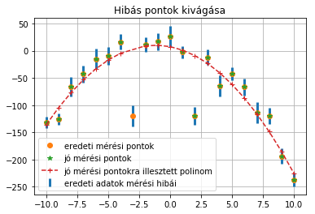

```python
plt.title("Hibás pontok kivágása")
plt.errorbar(x,y,sigma,ls='',lw=3,label='eredeti adatok mérési hibái')
plt.plot(x,y,marker='o',ls='',label='eredeti mérési pontok')
plt.plot(xx,yy,'*',label='jó mérési pontok')   # új pontok
plt.plot(xx,zz,'+--',label='jó mérési pontokra illesztett polinom')
plt.grid()
plt.legend()
```

## 3. feladat

Írjuk függvényt, mely meghatározza az illesztett paraméterek aszimptotikus hibáját és kovarianciáját.

A bevezetett $\mathbf{\alpha} = \mathbf{X}^{T} \mathbf{X}$ szimmetrikus mátrixról belátható, hogy annak $\mathbf{C} = \mathbf{\alpha}^{-1}$ inverze, az ún. kovarianciamátrix, jól jellemzi az illesztett paraméterek hibáját és kovarianciáját. Az $a_k$ paraméter hibája egyszerűen $\sigma_{a_k}^2 = C_{kk}$, míg az $a_k$ és $a_l$ paraméterek kovarianciája a $ \textrm{cov}(a_k, a_l) = C_{kl}$ mátrixelem.

```python
def kov(Mat):    # ahol Mat a tervmátrix
    alfa = np.dot(Mat.T,Mat)   # szimmetrikus mátrix
    C = np.linalg.inv(alfa)    # kovariancia mátrix
    return C
```

- Mat a tervmátrix,
- alfa a szimmetrikus mátrix,
- C pedig a kovarianciamátrix.

Így a kovariancia-mátrix az alábbi módon néz ki:

```python
kov(Mat)
```

```
array([[ 2.28247802e+01, -1.39401988e-01, -3.47799791e-01],
       [-1.39401988e-01,  2.40877579e-01,  3.99035857e-03],
       [-3.47799791e-01,  3.99035857e-03,  8.94578611e-03]])
```

## 4. feladat

Határozzuk meg a kilógó pontokat is tartalmazó adatsor esetében az illesztett parabola paramétereinek eloszlását és hibáját a bootstrap módszer segítségével. A bootstrap eljárás során az illesztést többször megismételjük oly módon, hogy mindig csak a mérési pontok egy véletlen részhalmazát (pl. 60%-át) használjuk fel az illesztéshez. Az így kapott illesztési paraméterekből készítsünk hisztogramot, valamint számítsuk ki a paraméterek várható értékét és szórását! Hasonlítsuk össze a kapott értékeket a kovarianciamátrixból számolt aszimptotikus hibával.

```python
# adatsorok kilógó pontokkal :
a, b, c = some_random_coeffs()
x, y, sigma = random_data_with_outliers(a, b, c, 10, 3)
```

Függvény az adatsorok részhalmazának kiválasztására, majd azokra történő illesztésre:

- bemeneti értékei:
  - x,y,sigma: maga az adatok
  - a: véletlen számok maximum értéke
  - b: véletlen számok darabszáma
- visszatérési értéke:
  - A: megfelelő oszlopaiban tartalmazza az új paramétereket

```python
def reszh_ill2(x,y,sigma,a,b):
    A = np.zeros((b,4))
    import random
    index = [random.sample(range(0,a), b)]
    xx = x[index]
    yy = y[index]
    ss = sigma[index]
    zz = illesztes(xx,yy,ss)
    A[:,0] = xx
    A[:,1] = zz
    A[:,2] = yy
    A[:,3] = ss
    return A
```

- tetszőlegesen sok mintavételezéssel elvégezzük az illesztéseket:

```python
fgh = reszh_ill2(x,y,sigma,21,15)
i = 0
while i <= 700:
    hmm = reszh_ill2(x,y,sigma,21,15)
    fgh=np.vstack((fgh,hmm[:,:]))
    i += 1
```

```python
# külön listába szedjük a később ábrázolni kívánt értékeket
xxx = fgh[:,0]
zzz = fgh[:,1]
```

### a bootstrap módszerrel kapott illesztési paraméterek eloszlása -- ábrák :

Az összes paraméter eloszlásának ábrázolása helyett nézzünk meg tetszőleges két értéket.

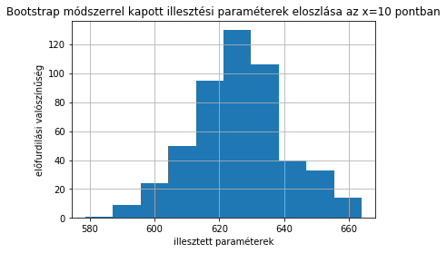

```python
plt.hist(zzz[xxx == 10])
plt.title('Bootstrap módszerrel kapott illesztési paraméterek eloszlása az x=10 pontban')
plt.ylabel('előfurdilási valószínűség')
plt.xlabel('illesztett paraméterek')
plt.grid()
```

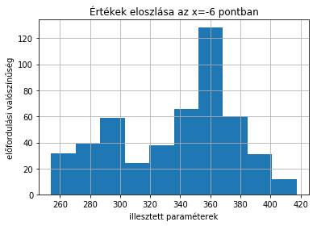

```python
plt.hist(zzz[xxx == -6])
plt.title('Értékek eloszlása az x=-6 pontban')
plt.xlabel('illesztett paraméterek')
plt.ylabel('előfordulási valószínűség')
plt.grid()
```

Írjunk függvényt a várható érték meghatározására, melynek

- bemenete x: adatsor
- visszatérési értéke maga a várható érték

```python
def expval(x):
    p = 1/len(x)
    sum = 0
    for i in range(0, len(x)):
        sum += (x[i] * p)
    return float(sum)
```

Kovariancia meghatározása:

```python
kovar = np.zeros(len(x))
k = min(xxx)
while k <= max(xxx):
    for j in range(0,len(x)):
        kovar[j] = np.cov(zzz[xxx == k])
        j = j+1
        k = k+1
```

Szórás meghatározása:

```python
szoras = np.zeros(len(x))
k = min(xxx)
while k <= max(xxx):
    for j in range(len(x)):
        szoras[j] = np.std(zzz[xxx == k])
        j = j+1
        k = k+1
```

Végül a várható érték:

```python
k = min(xxx)
varhato = np.zeros(len(x))
while k <= max(xxx):
    for j in range(len(xxx)):
        varhato[j] = expval(zzz[xxx == k])
        j = j+1
        k = k+1
```

Mivel tudjuk, hogy a várható értéket tekinthetjük a parabola illesztett értékeinek, illetve a kiszámolt szórásokat a hibáknak, így elkészíthetjük a parabolaillesztést.

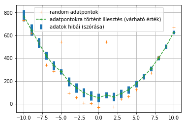

```python
plt.errorbar(x,varhato,szoras,ls='',lw=5,label='adatok hibái (szórása)')
plt.plot(x,y,marker='+',ls='',label='random adatpontok')
plt.plot(x,varhato,'+--',label='adatpontokra történt illesztés (várható érték)')
plt.grid()
plt.legend()
```

## Sikeres feladatmegoldást mindenkinek!